#### B. Dealing with the NA

```r
colSums(sapply(cleaned_airb_df, is.na))
```

```
##                price        property_type            room_type
##                    0                    0                    0
##             bedrooms             bed_type            bathrooms
##                   21                    0                   25
##      guests_included         extra_people         accommodates
##                    0                    0                    0
##       minimum_nights            host_name              host_id
##                    0                    0                    0
##    number_of_reviews review_scores_rating             latitude
##                    0                  854                    0
##            longitude    new_neighbourhood
##                    0                    0
```

```r
##################################################################################
## We convert "bedrooms" Na Values to 0 (assuming it's a studio-type property)
## We convert "bathrooms" Na Values to 1 (assuming every property has at least 1 bathroom
## We convert "review_scores_rating" Na Values with 0 as it refers to 0 review
## We convert "bathrooms" with 0 value to 1 (assuming every property has at least 1 bathroom)
##################################################################################

cleaned_airb_df$bedrooms[is.na(cleaned_airb_df$bedrooms)] <- 0
cleaned_airb_df$bathrooms[is.na(cleaned_airb_df$bathrooms)] <- 1
cleaned_airb_df$review_scores_rating[is.na(cleaned_airb_df$review_scores_rating)] <- 0
cleaned_airb_df$bathrooms[cleaned_airb_df$bathrooms == 0] <- 1

## Check if NA values are gone
colSums(sapply(cleaned_airb_df, is.na))
```

```
##                price        property_type            room_type
##                    0                    0                    0
##             bedrooms             bed_type            bathrooms
##                    0                    0                    0
##      guests_included         extra_people         accommodates
##                    0                    0                    0
##       minimum_nights            host_name              host_id
##                    0                    0                    0
##    number_of_reviews review_scores_rating             latitude
##                    0                    0                    0
##            longitude    new_neighbourhood
##                    0                    0
```

#### B. Converting to categorical data

```r
# Convert  to categorical data
temp <- cleaned_airb_df %>% mutate_at(vars(room_type, bedrooms, bed_type, bathrooms, host_name, host_id, review_scores_rating, new_neighbourhood, property_type, bed_type),list(factor))
str(temp)
```

```
## 'data.frame':    3696 obs. of  17 variables:
##  $ price               : num  160 350 95 99 100 149 150 175 239 65 ...
##  $ property_type       : Factor w/ 11 levels "Apartment","Bed & Breakfast",..: 8 8 8 3 6 1 1 1 8 1 ...
##  $ room_type           : Factor w/ 3 levels "Entire home/apt",..: 1 1 2 1 1 1 1 1 1 2 ...
##  $ bedrooms            : Factor w/ 9 levels "0","1","2","3",..: 2 4 2 3 3 2 2 2 3 2 ...
##  $ bed_type            : Factor w/ 5 levels "Airbed","Couch",..: 5 5 5 5 5 5 5 5 5 5 ...
##  $ bathrooms           : Factor w/ 12 levels "0.5","1","1.5",..: 2 6 2 2 4 2 2 3 2 2 ...
##  $ guests_included     : int  1 1 1 2 2 1 2 2 1 2 ...
##  $ extra_people        : num  0 0 0 25 40 99 20 25 0 0 ...
##  $ accommodates        : int  4 6 2 4 4 1 4 4 3 4 ...
##  $ minimum_nights      : int  1 2 1 1 3 3 2 1 5 2 ...
##  $ host_name           : Factor w/ 1537 levels "'G' (Gurinder)",..: 886 1280 297 1436 1013 110 715 986 972 1455 ...
##  $ host_id             : Factor w/ 2708 levels "1585","2798",..: 1570 818 1632 232 8 237 391 1399 1165 1877 ...
##  $ number_of_reviews   : int  0 65 0 0 0 46 84 25 4 2 ...
##  $ review_scores_rating: Factor w/ 42 levels "0","30","40",..: 1 36 1 1 1 42 41 33 42 42 ...
##  $ latitude            : num  38.9 38.9 38.9 38.9 39 ...
##  $ longitude           : num  -77 -77 -77 -77 -77 ...
##  $ new_neighbourhood   : Factor w/ 39 levels "Brightwood Park",..: 3 3 32 32 34 6 30 30 30 30 ...
```

```r
cleaned_airb_df <- temp
```

#### **Price Analysis**

##### **A. Checking Price Relationships with other variables**

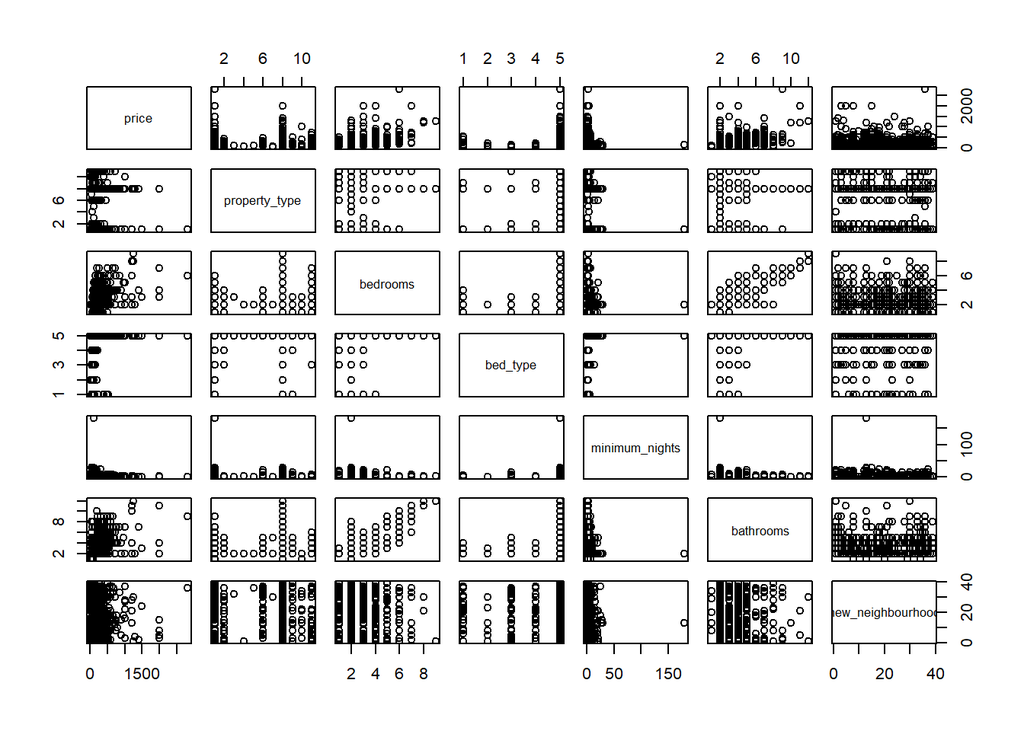

```r
pairs(~price+property_type+bedrooms+bed_type+minimum_nights+bathrooms+new_neighbourhood, data=cleaned_airb_df)
```

- **Interpretation**
  - There seems to have no clear patterns in the scatter plots that is interesting to do a linear correlation except for bedrooms and bathrooms variables.

##### **B. PRICE FREQUENCY**

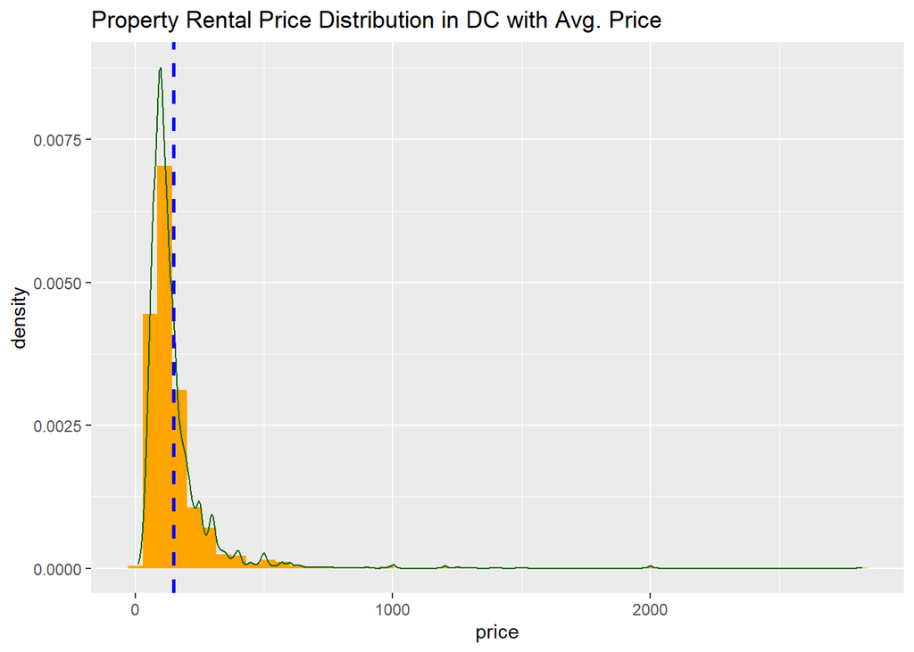

```r
## Histogram of Price Frequency
densplot <- ggplot(data = cleaned_airb_df, mapping = aes(x = price))+
  geom_histogram(aes(y=..density..), bins=50, fill = "orange")+
  geom_density(color='dark green') +
  ggtitle("Property Rental Price Distribution in DC with Avg. Price")

   densplot + geom_vline(aes(xintercept=mean(price)),
           color="blue", linetype="dashed", size=1)
```

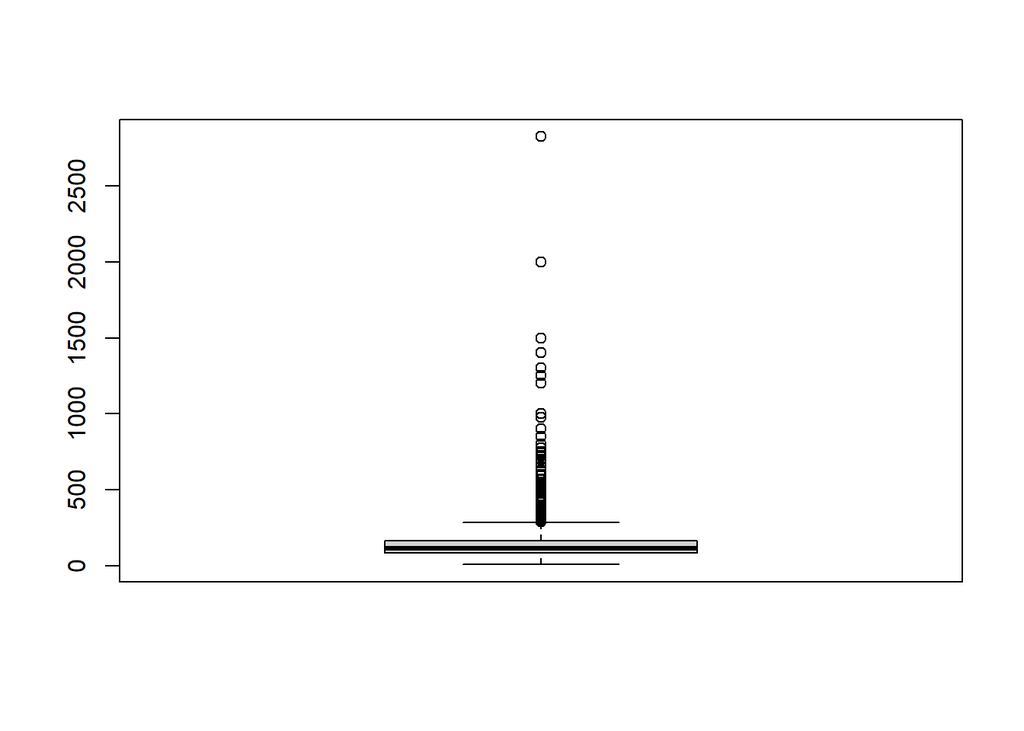

```r
##Checking outliers in property price
boxplot(cleaned_airb_df$price)
```

##### **B. PRICE BY NEIGHBORHOOD**

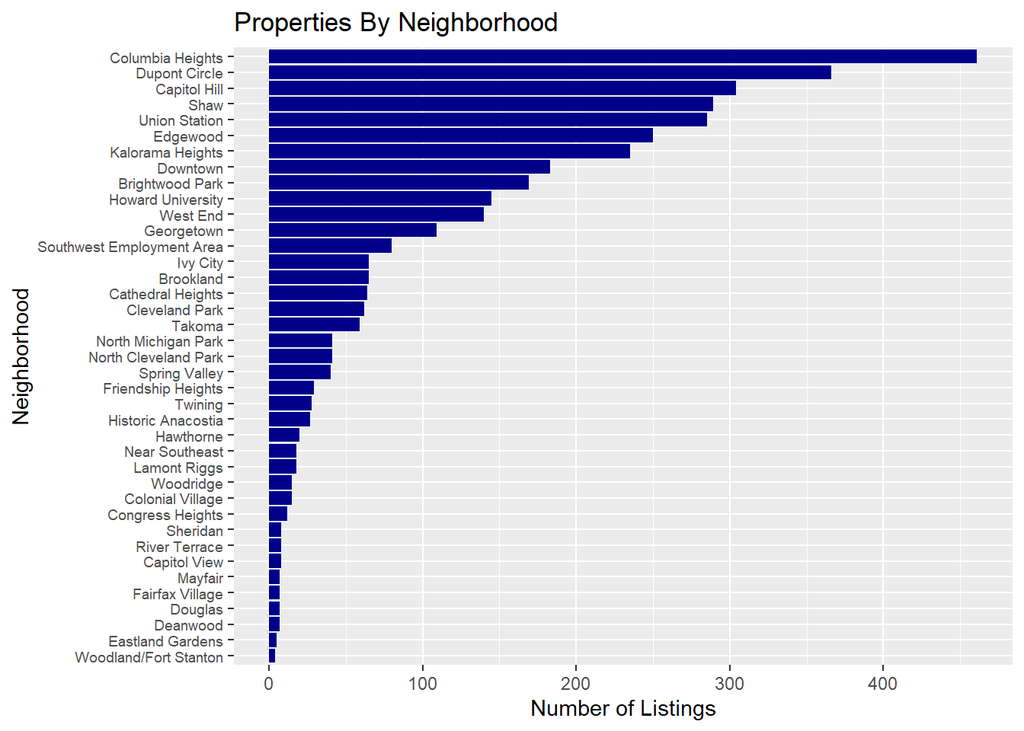

```r
## Group price by location and take average
p2 <- cleaned_airb_df %>%
        group_by(new_neighbourhood) %>%
        summarise(p_mean = mean(price),
                  p_median = median(price),
                  p_count= n()
                  )


ct <- ggplot(p2, mapping=aes(x=reorder(new_neighbourhood,p_count), y=p_count))+
  geom_col(fill="dark blue") +
  ggtitle("Properties By Neighborhood") +
  xlab("Neighborhood") +
  ylab("Number of Listings") +
  coord_flip() +
  theme(axis.text.y=element_text(size=rel(0.8)))

mn <- ggplot(p2, mapping=aes(x=reorder(new_neighbourhood,p_count), y=p_mean))+
  geom_col(fill="#5B84B1FF") +
  ggtitle("Mean Price By Neighborhood") +
  xlab("Neighborhood") +
  ylab("Mean Price") +
  coord_flip() +
  theme(axis.text.y=element_text(size=rel(0.8)))


md <-ggplot(p2, mapping=aes(x=reorder(new_neighbourhood,p_count), y=p_median))+
  geom_col(fill="dark green") +
  ggtitle("Median Price By Neighborhood") +
  xlab("Neighborhood") +
  ylab("Median Price") +
  coord_flip() +
  theme(axis.text.y=element_text(size=rel(0.8)))




ct
```

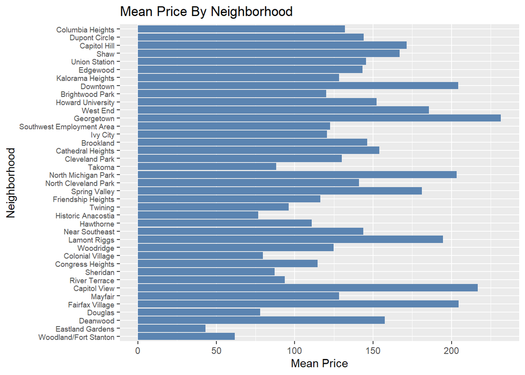

```r
mn
```

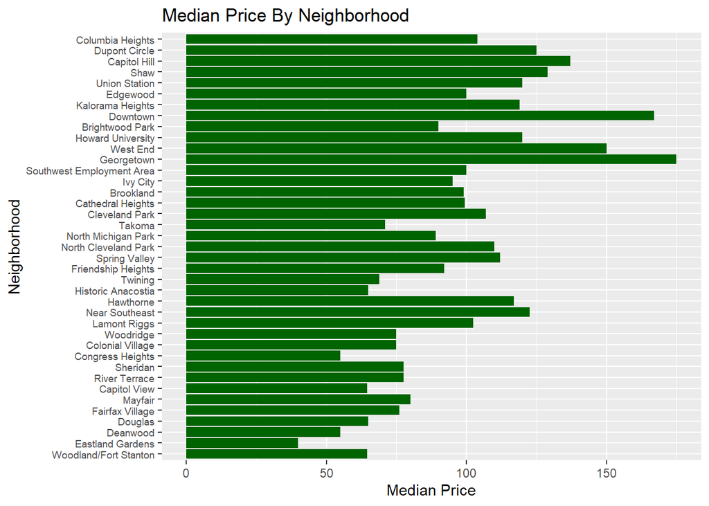

```r
md
```

- **Interpretation**
  - “Columbia Heights” has the most number of listings however the prices of the listings varies which affects the mean and median (price in Downtown has higher mean and median despite number of listings in the area are low)

##### **C. PRICE BY PROPERTY TYPE**

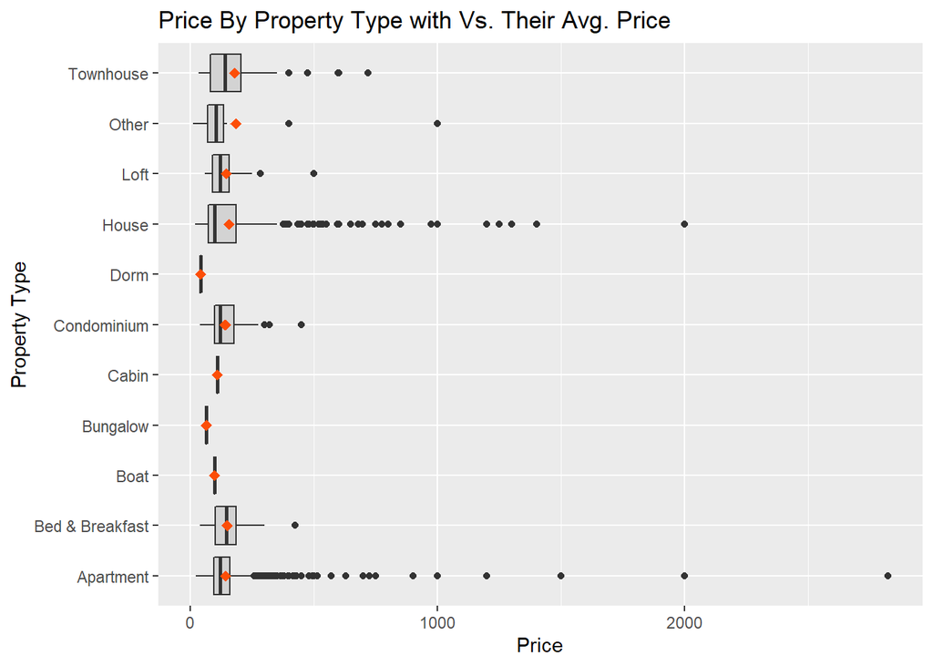

```r
##Checking outliers in property price with mean points
prop_type_outliers <- ggplot(cleaned_airb_df, aes(x = price, y = property_type))

prop_type_outliers + geom_boxplot(notch = FALSE, fill = "lightgray") +
  ggtitle("Price By Property Type with Vs. Their Avg. Price") +
  xlab("Price") +
  ylab("Property Type") +
  stat_summary(fun = mean, geom = "point",
               shape = 18, size = 2.5, color = "#FC4E07")
```

**Interpretation**

- We can see that “house” and “apartment” have many outliers than other types of property
  - The average price varies by property type

##### **D. PRICE BY ROOM TYPE**

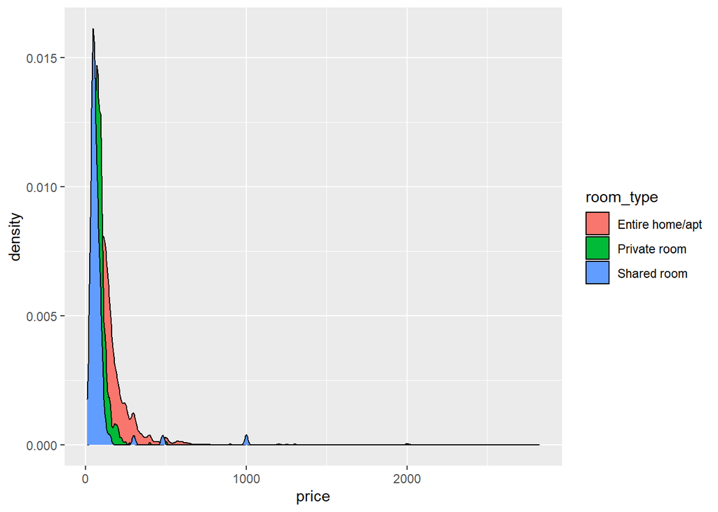

```r
ggplot(cleaned_airb_df, aes(x=price, fill=room_type)) +
  geom_density()
```

**Interpretation**

- According to the data, shared room has the most prices than any other room type

##### **E. Room TypeBy Neighbourhood Treemap**

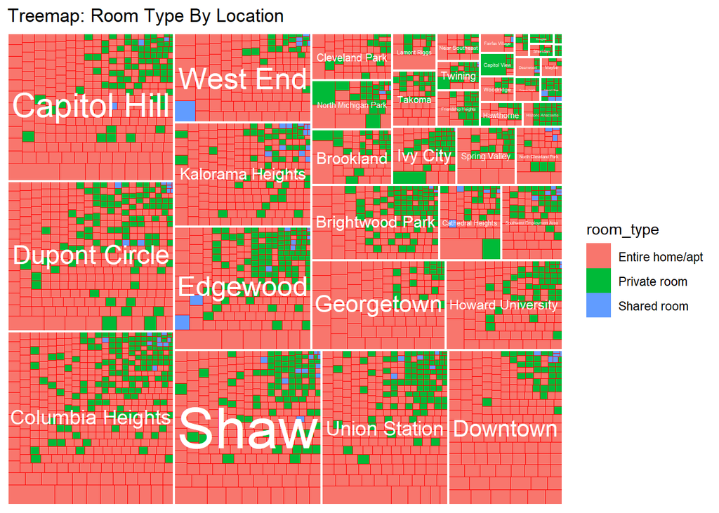

```r
tree_viz <- ggplot(cleaned_airb_df, aes(area = price, fill = room_type, subgroup = new_neighbourhood)) +
  geom_treemap(color = "red") +
  geom_treemap_subgroup_border(color = "white", size = 2) +
  geom_treemap_subgroup_text(place = "centre", grow = T, alpha = 1, colour =
                               "white", min.size = 1) +
  labs(title="Treemap: Room Type By Location")
tree_viz
```

##### **E.1. Property Type By Neighbourhood Treemap**

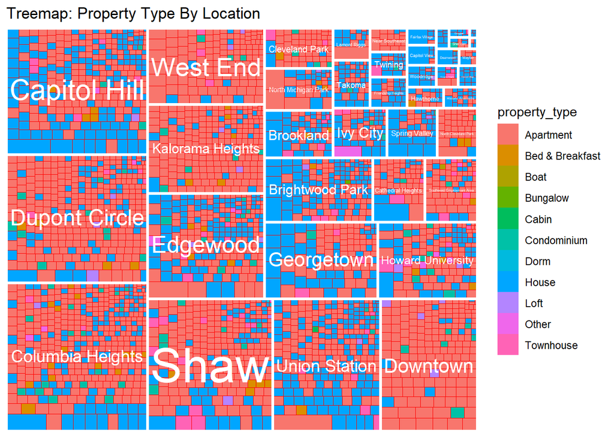

```r
tree_viz1 <- ggplot(cleaned_airb_df, aes(area = price, fill = property_type, subgroup = new_neighbourhood)) +
  geom_treemap(color = "red") +
  geom_treemap_subgroup_border(color = "white", size = 3) +
  geom_treemap_subgroup_text(place = "centre", grow = T, alpha = 1, colour =
                               "white", min.size = 1) +
  labs(title="Treemap: Property Type By Location")
tree_viz1
```

**Interpretation**

- The treemap depicts the rental prices among all room types and property types by location
  - This is to give an overview of prices by room_type and property types per location
  - Capitol Hill and Union Station seems to have high rental price for “Entire home/apt” in “E. Room TypeBy Neighbourhood Treemap” while it also have high price in “house” property type in “E.1. Property Type By Neighbourhood Treemap”
  - In “E.1. Property Type By Neighbourhood Treemap” West End“,”Downtown" and “Kalorama Heights” has the most apartments compare to other property types in their respective areas.

##### **F. Price By Number of Bedrooms**

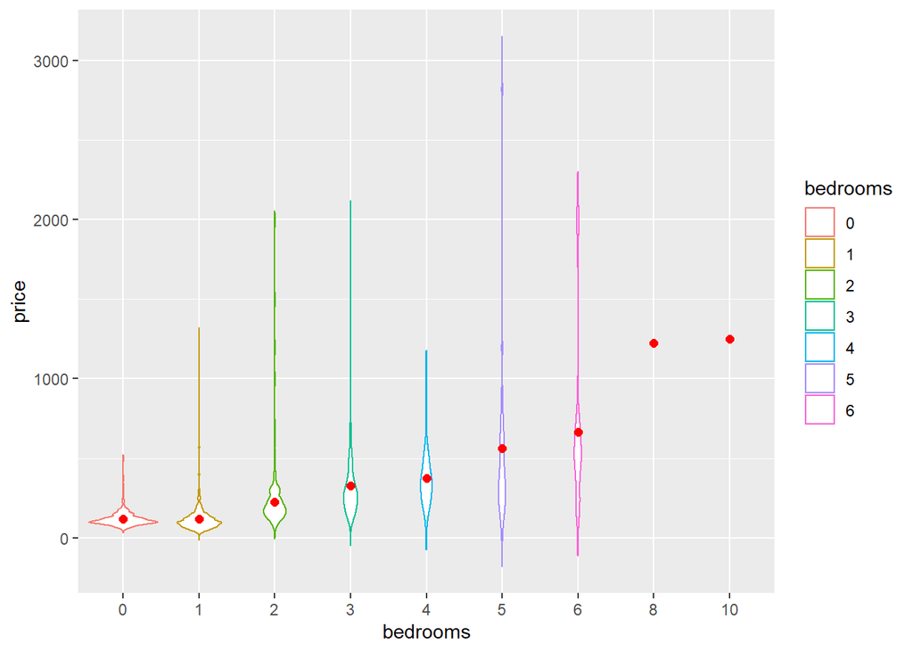

```r
violin_bdrm <- ggplot(cleaned_airb_df, aes(x=price, y=bedrooms, color=bedrooms)) +
  geom_violin(trim=FALSE) +
   coord_flip() +
   stat_summary(fun=mean, geom="point", size=2, color="red")

violin_bdrm
```

**Interpretation**

- The violin plot represents the distribution of price per number of bedrooms related to their outlier prices
  - It shows there are many properties with 0 bedrooms (assuming it is a studio type apartment) and rental prices are just below $100.
  - It shows that the 5 bedrooms has a wide range of min to max prices

##### **F. Number of Bedrooms by Property Type**

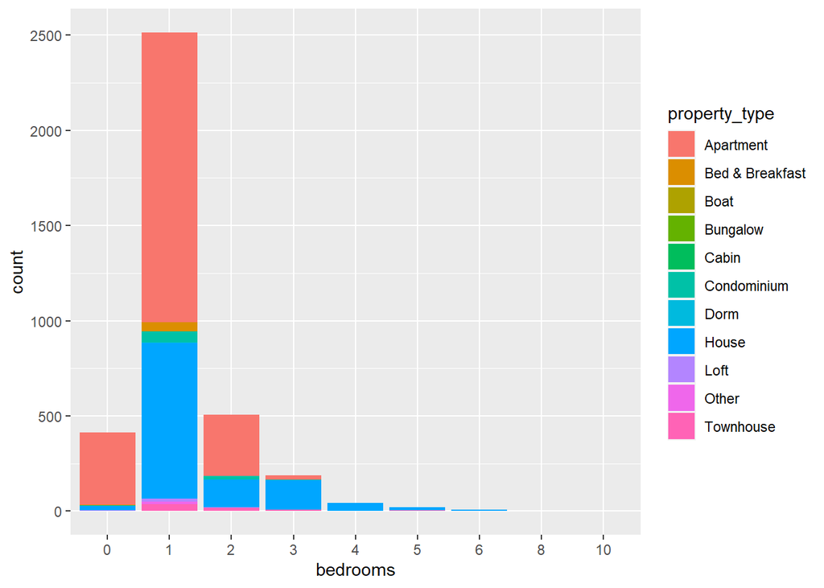

```r
ggplot(cleaned_airb_df, aes(x=bedrooms, fill=property_type)) +
  geom_bar()
```

##### **H. Property Type by BedType**

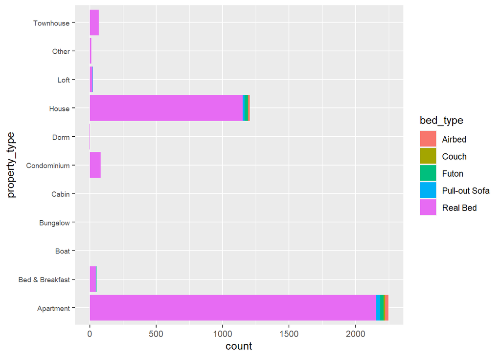

```r
ggplot(cleaned_airb_df, aes(x=property_type, fill=bed_type)) +
  geom_bar() +
   coord_flip() +
  theme(axis.text.y=element_text(size=rel(0.8)))
```

**Interpretation**

- Many of the property types are using “read beds” than any other bedtype
  - The data shows that the least number of bed type being used is couch

##### **I. Number Accommodates by Property Type**

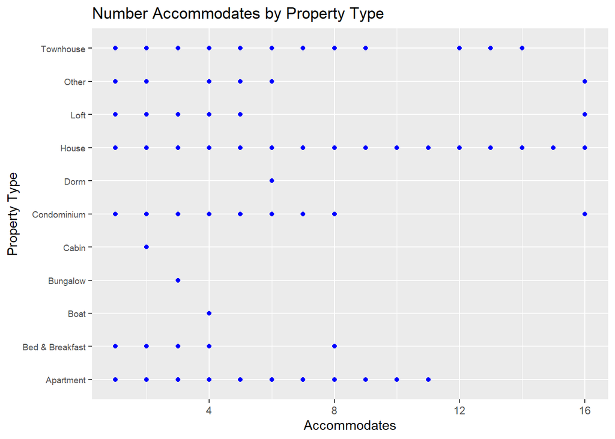

```r
pss <- ggplot(cleaned_airb_df, aes(property_type, accommodates))
pss + geom_point(colour="blue") +
   coord_flip() +
   ylab("Accommodates") +
   xlab("Property Type") +
   ggtitle("Number Accommodates by Property Type") +
  theme(axis.text.y=element_text(size=rel(0.8)))
```

**Interpretation**

- House has the most flexible number of accommodations among all the property types
  - Dorm seems to accept up to 6 people in one stay while boat can take up to 4 people

##### **I. Number of Reviews by Property Type**

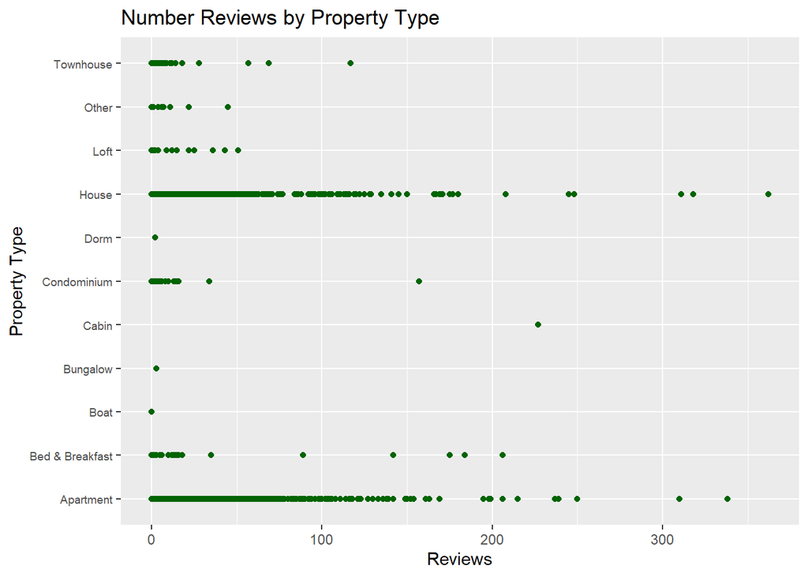

```r
pss <- ggplot(cleaned_airb_df, aes(property_type, number_of_reviews))
pss + geom_point(colour="dark green") +
   coord_flip() +
   ylab("Reviews") +
   xlab("Property Type") +
   ggtitle("Number Reviews by Property Type") +
  theme(axis.text.y=element_text(size=rel(0.8)))
```

**Interpretation**

- Reviews indicate the number of people who have stayed and left a review
  - House and Apartment has the most number of reviews which could possibly mean that during this time of the data was captured, House and Apartment property types are the most stayed property type.

##### **J. Listing Map**

```r
expensive_listings <- cleaned_airb_df %>%
  filter(cleaned_airb_df$price >= 500)

inexpensive_listings <- cleaned_airb_df %>%
  filter(cleaned_airb_df$price < 500)

listing_map <- leaflet() %>%
   addTiles() %>%
   setView(lng = -77.046331, lat = 38.909702 , zoom = 12) %>%
   addCircleMarkers( lng = inexpensive_listings$longitude,
                     lat = inexpensive_listings$latitude,
                     radius = 2,
                     stroke = FALSE,
                     color = "blue",
                     fillOpacity = 0.5,
                     group = "Inexpensive Properties"
                     )  %>%
   addCircleMarkers( lng = expensive_listings$longitude,
                     lat = expensive_listings$latitude,
                     radius = 4,
                     stroke = FALSE,
                     color = "red",
                     fillOpacity = 0.5,
                     group = "Expensive Properties"
                     )


listing_map
```

[interactive chart not shown]

**Interpretation**

- The listings map above represents the high price rental properties (price above $500) vs. low price (price below $500) properties
  - Looking at the map alone does not clearly specify patterns of high price based on just the location having features such as “prime spot”, or “near the park”, “near the airport” , “near the river” , etc.

#### 7. Summary & Conclusions

The data analysis done above a great stat to give insights about pricing by different variables.

**Problem Statements**

- How are the listings distributed by location, by price, by type of property?
  - They are distributed around Washington DC and the price varies by property type, number of bedrooms and perhaps some other variables that is not covered by our dataset
- Which neighborhoods has the most expensive listings in DC?
  - In the “Listing Map” map section, it shows the distribution of high priced listing compare to low priced listings by map level. However in the “B. PRICE BY NEIGHBORHOOD” section, it states that based on median price, Georgetown neighbourhood has the highest price.
- What are the different types of listings in DC? Does their price vary by neighborhood?
  - These includes Townhouse, Loft, House, Dorm, Condominium, Cabin, Bungalow, Boat, Bed & Breakfast, Apartment
  - In the “E. Room Type Treemap” section, it shows the prices by room type per location which gives us a rough idea of prices by neighborhood
- Is there a relationships between price and other variables in the listing?
  - This part needs further analysis and perhaps would need more variables in the dataset or perhaps analyse the “description” column and extract details about property features.

However we can also do further analysis on:

- Price with date and time to determine demand/supply of house price rentals in the location
- Revenue with all variables (similar to pricing analysis) to determine which location is best to invest an airbnb property

#### 8. References

- http://www.sthda.com/english/articles/32-r-graphics-essentials/132-plot-grouped-data-box-plot-bar-plot-and-more/
- https://www.kaggle.com/chrisbow/e-commerce-eda-and-segmentation-with-r
- https://rkabacoff.github.io/datavis/Bivariate.html
- https://www.kaggle.com/notaapple/detailed-exploratory-data-analysis-using-r
- https://analyticsindiamag.com/tutorial-get-started-with-exploratory-data-analysis-and-data-preprocessing/
- https://learn.r-journalism.com/en/mapping/leaflet_maps/leaflet/